# STATS 506 Homework 3 Problem 4

Yunbin Peng

November 12, 2017

**Dataset used**:  
NYCflights14  
**Data URL**:  
https://raw.githubusercontent.com/wiki/arunsrinivasan/flights/NYCflights14/flights14.csv  
**Description**:  
This script has 2 main parts:  
1. Display a network map of flight originating from 3 NYC airports to different destinations, with thickness of edges(route) proportional to weekly average frequency of flights, using geom_curve function.  
2. Compute pairwise distances between carriers based on frequency of flights between airports and produce 2-dimensional map of carrier using multidimensional scaling. Then repeat based on normalized frequency and compare results between two approaches.

### Data Preperation

```r
# load packages
library(data.table)
library(ggplot2)
library(dplyr)
library(tidyverse)

# load NYCflights14 data set
nyc14 = fread(
  'https://raw.githubusercontent.com/wiki/arunsrinivasan/flights/NYCflights14/flights14.csv')
```

### a

```r
# number of weeks
weeks = (365-30-31)/7

# compute number of flights per week from each origin to each destination
weekly_flights = nyc14[, .("No_flights" = .N / weeks), by = .(origin, dest)]

# display first 10 rows of result
knitr::kable(weekly_flights[1:10], digits=2,
             col.names = c('Origin', 'Destination', 'Number of flights per week '))
```

| Origin | Destination | Number of flights per week |
| --- | --- | --- |
| JFK | LAX | 235.05 |
| LGA | PBI | 53.12 |
| EWR | LAX | 97.31 |
| JFK | MIA | 63.32 |
| JFK | SEA | 41.79 |
| EWR | MIA | 48.22 |
| JFK | SFO | 169.66 |
| JFK | BOS | 94.66 |
| JFK | ORD | 29.13 |
| JFK | IAH | 0.16 |

### b

```r
# load dataset from problem 3
load("airportCoord.RData")

# function to find mds coordinates for airport
get_coord_x = function(target, data = airportCoord) {
  return(airportCoord[airport == target, x])
}
get_coord_y = function(target, data = airportCoord) {
  return(airportCoord[airport == target, y])
}

# generate data set
weekly_flights1 = weekly_flights[ , "origin_x" := sapply(origin, get_coord_x)] %>%
  .[, "origin_y" := sapply(origin, get_coord_y)] %>%
  .[, "dest_x" := sapply(dest, get_coord_x)] %>%
  .[, "dest_y" := sapply(dest, get_coord_y)] %>%
  .[, "relative_flight_frequency" := No_flights / max(No_flights)]

# display first 10 rows of result
knitr::kable(weekly_flights1[1:10], digits=2)
```

| origin | dest | No_flights | origin_x | origin_y | dest_x | dest_y | relative_flight_frequency |
| --- | --- | --- | --- | --- | --- | --- | --- |
| JFK | LAX | 235.05 | 744.43 | 410.60 | -1596.24 | -377.34 | 1.00 |
| LGA | PBI | 53.12 | 736.21 | 417.56 | 718.42 | -628.08 | 0.23 |
| EWR | LAX | 97.31 | 724.12 | 406.28 | -1596.24 | -377.34 | 0.41 |
| JFK | MIA | 63.32 | 744.43 | 410.60 | 723.36 | -691.24 | 0.27 |
| JFK | SEA | 41.79 | 744.43 | 410.60 | -1674.02 | 600.74 | 0.18 |
| EWR | MIA | 48.22 | 724.12 | 406.28 | 723.36 | -691.24 | 0.21 |
| JFK | SFO | 169.66 | 744.43 | 410.60 | -1787.37 | -88.04 | 0.72 |
| JFK | BOS | 94.66 | 744.43 | 410.60 | 827.58 | 577.14 | 0.40 |
| JFK | ORD | 29.13 | 744.43 | 410.60 | 18.34 | 275.63 | 0.12 |
| JFK | IAH | 0.16 | 744.43 | 410.60 | -237.61 | -617.44 | 0.00 |

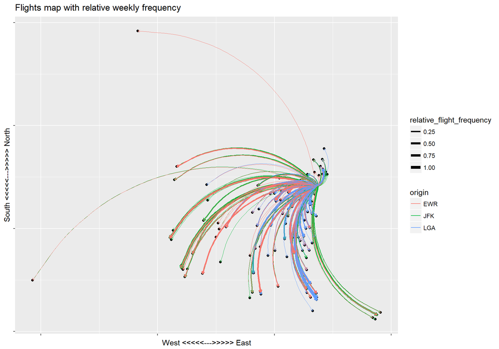

```r
# network diagram using geom_curve
ggplot(data = weekly_flights1, aes(x = dest_x, y = dest_y)) + geom_point() +
  geom_curve(aes(x = origin_x, y = origin_y,
                 xend = dest_x, yend = dest_y,
                 size = relative_flight_frequency,
                 color = origin),
             arrow = arrow(length = unit(0.008, "npc")),
             alpha = 1, curvature = 0.4) + scale_size(range = c(0, 2)) +
  labs(x = "West <<<<<--->>>>> East", y = "South <<<<<--->>>>> North",
       title = "Flights map with relative weekly frequency") +
  theme(axis.text.x=element_blank(), axis.text.y=element_blank())
```

### c

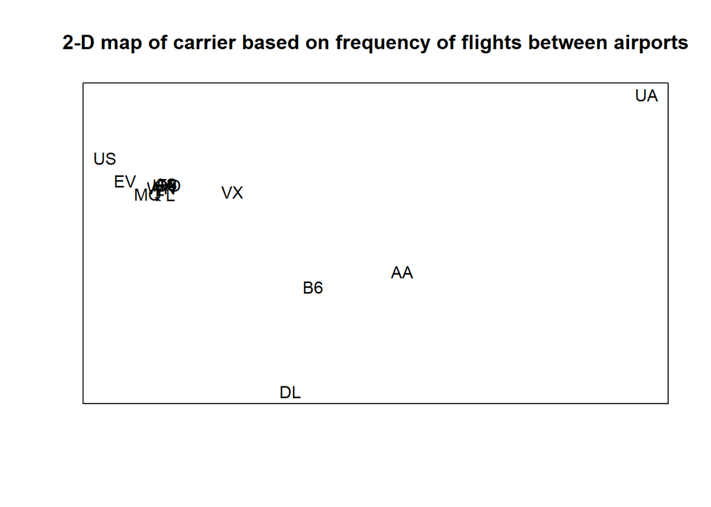

```r
# for each origin and destination, find average flight per week for each carrier
carrier_flight = nyc14[, .("No_flights" = .N / weeks), by = .(origin, dest, carrier)] %>%
  .[, "flight" := paste(origin, dest, sep = " to ")] %>%
  .[, c("origin", "dest") := NULL]

# convert data.table from long to wide format
carrier_matrix = dcast(carrier_flight, carrier~flight, value.var = "No_flights")

# replace missing value as 0
carrier_matrix[is.na(carrier_matrix)] = 0

# find list of carrier
carriername = carrier_matrix[, carrier]

# remove 1st column of carrier_matrix
carrier_matrix = carrier_matrix[, "carrier" := NULL]

# convert into matrix
carrier_matrix = as.matrix(carrier_matrix)
rownames(carrier_matrix) = carriername

# compute pairwise distance between carriers
distance.carrier = dist(carrier_matrix, method = "euclidean", diag = TRUE, upper = TRUE)

# multidimensional scaling on carrier
carrierMDS = cmdscale(distance.carrier)
plot(carrierMDS, pch='', xlab=' ', ylab=' ', bg='grey', xaxt='n', yaxt='n',
     main = "2-D map of carrier based on frequency of flights between airports")
text(carrierMDS, attr(distance.carrier, 'Labels'))
```

I observe that most of carriers are clustered together while 4 carriers (B6, AA, DL and UA) are relatively far away from most of other carriers, especially for UA. This means those 4 carriers have relatively different frequency of flights between airports as compared to others.

### d

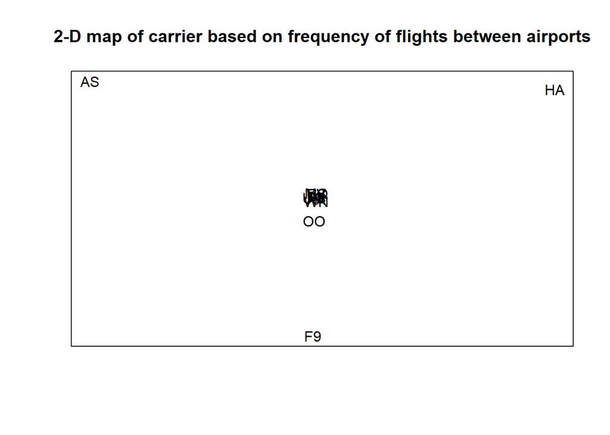

```r
# for each origin, destination and carrier, find average number of flights per week
# for each carrier, normalize average number of flights by total number of flights
carrier_flight = nyc14[, .("No_flights" = .N / weeks), by = .(origin, dest, carrier)] %>%
  .[, "flight" := paste(origin, dest, sep = " to ")] %>%
  .[, "Scaled_No_flights" := No_flights / sum(No_flights), by = .(carrier)] %>%
  .[, c("origin", "dest", "No_flights") := NULL]

# convert data.table from long to wide format
carrier_matrix = dcast(carrier_flight, carrier~flight, value.var = "Scaled_No_flights")

# replace missing value as 0
carrier_matrix[is.na(carrier_matrix)] = 0

# find list of carrier
carriername = carrier_matrix[, carrier]

# remove 1st column of carrier_matrix
carrier_matrix = carrier_matrix[, "carrier" := NULL]

# convert into matrix
carrier_matrix = as.matrix(carrier_matrix)
rownames(carrier_matrix) = carriername

# compute pairwise distance between carriers
distance.carrier = dist(carrier_matrix, method = "euclidean", diag = TRUE, upper = TRUE)

# multidimensional scaling on carrier
carrierMDS = cmdscale(distance.carrier)
plot(carrierMDS, pch='', xlab=' ', ylab=' ', bg='grey', xaxt='n', yaxt='n',
     main = "2-D map of carrier based on frequency of flights between airports")
text(carrierMDS, attr(distance.carrier, 'Labels'))
```

After normalizing frequency data for average weekly number of flights by each carrier (i.e. use proportion of flights specific route between between origin and destination), I observe that most carriers are very close to one another as there is a cluster of carriers in the center of the map, while there are 3 carriers (AS, F9 and HA) that are significantly far away from the cluster. This result is interesting as those 3 carriers are not “outliers” in 2-d map in part c. In fact there is a bias due to volume of flights for carriers in part c which I will explain with a toy example later.

Normalization actually reduce that bias and give a better comparison between carriers. Therefore I conclude **those 3 carriers (AS, HA, F9) have a very different flight networks than others.** For example they may have a much higher proportion of flights to a few destinations to where other carriers do not have flight.

If we actually look at those 3 carriers, we can see they almost exclusively fly to 1 or 2 destinations.

```r
carrier_flight[carrier %in% c("AS", "F9", "HA")] %>% .[order(carrier)]
```

```
##    carrier     flight Scaled_No_flights
## 1:      AS EWR to SEA        1.00000000
## 2:      F9 LGA to DEN        0.98731501
## 3:      F9 LGA to CLE        0.01268499
## 4:      HA JFK to HNL        1.00000000
```

**This is optional**

I will use a toy example to explain differences in approaches in part c and d.  
Suppose there are 3 carriers (A, B and C)  
Carrier A has 2 weekly flight from NYC to LA, 1 flight from NYC to SF and 1 flight from NYC to SD.  
Carrier B has 2 weekly flight from NYC to LA, 2 flight from NYC to SF and 1 flight from NYC to SD.  
Carrier C has 200 weekly flight from NYC to LA, 100 flight from NYC to SF and 100 flight from NYC to SD.

It is easy to tell carrier C is basically a scaled up version of carrier A. However in part c, pairwise distance between carriers is computed based on absolute values of frequency, therefore there is **greater distance between Carrier A and C** than between Carrier A and B.

In part d we compute pairwise distance based on normalized frequency, so if we divide frequency data from total number of flights for each carrier, we will get  
Carrier A has 50% flights from NYC to LA, 25% flights from NYC to SF and 25% flight from NYC to SD. Carrier B has 40% flights from NYC to LA, 40% flights from NYC to SF and 20% flight from NYC to SD. Carrier C has 50% flights from NYC to LA, 25% flights from NYC to SF and 25% flight from NYC to SD.

After normalization to proportion, there is **no distance between Carrier A and C** while there is some distance betwee Carrier A and B. Hence we conclude pairwise distance based on normalized frequency is a better representation of difference in network between carriers.